# Jubaclassifier Hands-on

[figure not shown]

主に書籍の内容について、コードを実行しながら説明します

データは書籍とは違うものを使います。

## Agenda

1. 分類とは
2. 実際に動かしてみる

### 分類とは

分類(Classifier)とは、与えられたデータに対して**適切なクラスを推定する処理**を指します。

- スパムメール判定
- 金融における顧客のデフォルト(不払い)予測
- etc ...

### 分類のイメージ

Harry Potterの組み分け帽を例にとる

[figure not shown]

### 線形分類器 VS 非線形分類器

- 線形分類器 : 空間を**直線/平面**で区切っていく
  - シンプルで早いが、**どうしても分けられない**場合も出てくる
- 非線形分類器 : 空間を**曲線/曲面**で区切っていく
  - 精度はいいが、**過学習**の恐れあり

[figure not shown]

## 実際に動かしてみる

実際にjubaclassifierを動かすことで、 Jubatusについて、分類について学んでいきましょう。

## 立ち上げ

### 用意したdockerの人

- 下記コマンドを実施

  ```
  $ docker run -p 8888:8888 -it jubatus/hands-on-5th /bin/bash
  $ jupyter notebook &
  ```

- http://127.0.0.1:8888 にアクセス

### VM、すでに環境がある人

- hands-on-5thフォルダまで行き、jupyter notebookを立ち上げる

## 手順

- Step0. 環境の確認
- Step1. Jubatusの起動
- Step2. データの読み込み、Datumに変換
- Step3. 作成したDatumをJubatus
- Step4. 学習モデルを用いて分類を行う
- Step5. 結果の分析をしてみる
- Step6. 前処理をしてみる
- Step7. 指標のトレードオフ

### Step0. 環境の確認

環境に、以下のものが入っているか確認してください。

- Jubatus
- Pythonライブラリ(jubaclassifierハンズオン用)
  - **`jupyter`, `jubatus`, `scikit-learn`**
  - **`numpy`, `pandas`, `matplotlib`**
- Pythonライブラリ(Jubakit, Python pluginハンズオン用)
  - **`jubakit`, `Cython`, `embedded_jubatus`, `statsmodels`**

### 配布物

下記のものがフォルダ**`hands-on-5th/classifier`**内にあるか確認してください。

- スクリプト(Python Notebookで配布します)
  - `hands_on.ipynb`
- データ(data/配下)
  - `default_train.csv`
  - `default_test.csv`
- コンフィグファイル(config/配下)
  - `linear.json` (AROW)
  - `nonlinear.json` (NN/Euclid LSH)

## Step1. Jubatusを起動

- ターミナルに戻り、下記コマンドを入力します
- 線形分類器(AROW)を使ってみます

`$ jubaclassifier -f config/linear.json -t 1000&`

### Jubatus分類器に入っているアルゴリズム

Jubatusでは、線形分類器と非線形分類器にそれぞれ下表のアルゴリズムを用意しています。

[figure not shown]

### Regularization Weghtとは

`Regularization_weight`が大⇛新しく入ってきたデータを何が何でも分類する

[figure not shown]

## Step2. データを読み込み、Datumに変換

- 今回扱うデータ : **default of credit card clients Data Set**
  - 台湾の顧客に対し、支払いの**不払い(デフォルト)があったかどうか**を集めたデータ
  - 年齢や性別など、**23個の特徴量**で構成されている

※本とは違うデータを用いています。

前処理等で、コードが少し異なる箇所もありますが、流れは本のままです。

- **`DEFAULT`**に支払いが履行されたかどうかの情報が含まれている
- **`DEFAULT`**を分類器の答え合わせ（正解ラベル)に用いる

| 列番 | 特徴量 | 概要 | 特徴量の型 |
| --- | --- | --- | --- |
| X1 | Amount of the given credit | 信用貸付額 | 整数 |
| X2 | Gender | 性別 | カテゴリ変数 |
| X3 | Education | 学歴 | カテゴリ変数 |
| X4 | Martial status | 結婚歴 | カテゴリ変数 |
| X5 | Age | 年齢 | 整数 |
| X6-X11 | History of past payment | 過去の支払い。きちんと支払ったかどうか(※1) | 整数 |
| X12-X17 | Amount of bill statememt | 過去の請求額(※1) | 整数 |
| X18-X23 | Amount of previous payment | 過去の支払額(※1) | 整数 |
| Y | DEFAULT | デフォルトしたかどうか | カテゴリ変数（正解ラベル） |

※1 2005年4月から2005年9月までの６ヶ月分のデータ

### Pandasを使ってデータを読み込んでみる

```python
import pandas as pd
df = pd.read_csv("data/default_train.csv") #データの読み込み
df.head()
```

|  | X1 | X2 | X3 | X4 | X5 | X6 | X7 | X8 | X9 | X10 | ... | X15 | X16 | X17 | X18 | X19 | X20 | X21 | X22 | X23 | Y |
| --- | --- | --- | --- | --- | --- | --- | --- | --- | --- | --- | --- | --- | --- | --- | --- | --- | --- | --- | --- | --- | --- |
| 0 | 20000 | 2 | 2 | 1 | 24 | 2 | 2 | -1 | -1 | -2 | ... | 0 | 0 | 0 | 0 | 689 | 0 | 0 | 0 | 0 | 1 |
| 1 | 120000 | 2 | 2 | 2 | 26 | -1 | 2 | 0 | 0 | 0 | ... | 3272 | 3455 | 3261 | 0 | 1000 | 1000 | 1000 | 0 | 2000 | 1 |
| 2 | 90000 | 2 | 2 | 2 | 34 | 0 | 0 | 0 | 0 | 0 | ... | 14331 | 14948 | 15549 | 1518 | 1500 | 1000 | 1000 | 1000 | 5000 | 0 |
| 3 | 50000 | 2 | 2 | 1 | 37 | 0 | 0 | 0 | 0 | 0 | ... | 28314 | 28959 | 29547 | 2000 | 2019 | 1200 | 1100 | 1069 | 1000 | 0 |
| 4 | 50000 | 1 | 2 | 1 | 57 | -1 | 0 | -1 | 0 | 0 | ... | 20940 | 19146 | 19131 | 2000 | 36681 | 10000 | 9000 | 689 | 679 | 0 |

5 rows × 24 columns

### データの読み込み

- **pandas**を用いてデータを読み込む
- 特徴量ベクトル, ラベル, 特徴量の名前をcsvから出力

```python
def read_dataset(path):
    df = pd.read_csv(path)
    labels = df['Y'].tolist()
    df = df.drop('Y', axis=1)
    features = df.as_matrix().astype(float)
    columns = df.columns.tolist()
    return features, labels, columns

features_train, labels_train, columns = read_dataset("data/default_train.csv")
```

```python
print("columns : \n{}\n".format(columns))
print("features : \n{}".format(features_train))
```

```
columns :
['X1', 'X2', 'X3', 'X4', 'X5', 'X6', 'X7', 'X8', 'X9', 'X10', 'X11', 'X12', 'X13', 'X14', 'X15', 'X16', 'X17', 'X18', 'X19', 'X20', 'X21', 'X22', 'X23']

features :
[[  2.00000000e+04   2.00000000e+00   2.00000000e+00 ...,   0.00000000e+00
    0.00000000e+00   0.00000000e+00]
 [  1.20000000e+05   2.00000000e+00   2.00000000e+00 ...,   1.00000000e+03
    0.00000000e+00   2.00000000e+03]
 [  9.00000000e+04   2.00000000e+00   2.00000000e+00 ...,   1.00000000e+03
    1.00000000e+03   5.00000000e+03]
 ...,
 [  1.60000000e+05   1.00000000e+00   6.00000000e+00 ...,   4.50000000e+03
    4.50000000e+03   4.50000000e+03]
 [  8.00000000e+04   1.00000000e+00   2.00000000e+00 ...,   5.52000000e+03
    0.00000000e+00   2.99800000e+03]
 [  2.10000000e+05   1.00000000e+00   3.00000000e+00 ...,   1.00000000e+03
    1.80000000e+03   1.40150000e+04]]
```

### 学習用データをDatum形式に変換

- Jubatusにデータを投げるために、pandasで読み込んだデータを**Datum形式**にする必要がある
- データと正解ラベルを1セットにしてデータを保持

**[(正解ラベル, Datum(key, value))]**

```python
from jubatus.common import Datum
features_train, labels_train, columns = read_dataset('data/default_train.csv')
train_data = []
for x, y in zip(features_train, labels_train):
    d = Datum({key: float(value) for key, value in zip(columns, x)})
    train_data.append([str(y), d])
```

## Step3. 作成したDatumをJubatusサーバに投入

```python
from jubatus.classifier.client import Classifier
# Jubatusサーバのホストとポートを指定する
client = Classifier('127.0.0.1', 9199, '')
#過去の学習結果を一度初期化する(任意)
client.clear()
# 学習を実行
client.train(train_data)
```

```
24998
```

## Step4. 学習モデルを用いて分類を行う

- 作った学習モデルを使って、実際に分類をしてみる
- **`data/default_test.csv`**を用いる

※実際の評価の際は、Cross Validationなどがよく使われます。

```python
# テスト用Datumリストを作る
features_test, labels_test, columns = read_dataset('data/default_test.csv')
test_data = []
for x, y in zip(features_test, labels_test):
    d = Datum({key: float(value) for key, value in zip(columns, x)})
    test_data.append(d)
```

### テストをする

実際にJubaclassifierにデータを投入し、返ってくるラベルを見る

```python
# テストをする
results = client.classify(test_data)
```

Jubatusがdefaultに対して、  
**yes/no**どちらが可能性が高いかをスコアリングしてくれている

```python
results[0]
```

```
[estimate_result{label: 1, score: 0.352370560169},
 estimate_result{label: 0, score: 0.909548699856}]
```

## Step5. 結果の分析を行う

- 先ほどのスコアの大きい方を分類結果として返す`get_most_likely`関数を作る
- 結果の混合行列, accuracy, precision, recall, F-valueを算出する

```python
# 結果を分析する(スコアの大きい方のラベルを選ぶだけ)
def get_most_likely(result):
    return max(result, key = lambda x: x.score).label
```

### 分類結果の評価指標

- 分類結果は、  
  **正例か負例か**という観点と、  
  **答えが合ってたかどうか**という観点で４種類に分けられる
- 分類した結果が...
  - Default **有** : 正例(**Positive**)
  - Default **無** : 負例(**Negative**)
- 推定結果が...
  - 正しい : **True**
  - 間違ってる : **False**

### 混合行列(Confusion Matrix)

この4種類を一つの表にまとめたもの

### 精度の評価指標

一口に『**精度**』と言っても、実はいろいろある

[figure not shown]

目的に応じて、見るべき指標は変わる

```python
def analyze_results(labels, results, pos_label="1", neg_label="0"):
    tp, fp, tn, fn = 0, 0, 0, 0
    for label, result in zip(labels, results):
        estimated = get_most_likely(result)
        label = str(label)
        estimated = str(estimated)
        if label == pos_label and label == estimated:
            tp += 1
        elif label == pos_label and label != estimated:
            fn += 1
        elif labels != pos_label and label == estimated:
            tn += 1
        else:
            fp += 1
    accuracy = float(tp + tn) / float(tp + tn + fp + fn)
    precision = float(tp) / float(tp + fp)
    recall = float(tp) / float(tp + fn)
    f_value = 2.0 * recall * precision / (recall + precision)
    # confusion matrix
    confusion = pd.DataFrame([[tp, fp], [fn, tn]], index=[pos_label, neg_label], columns=[pos_label, neg_label])
    return confusion, accuracy, precision, recall, f_value
```

```python
confusion, accuracy, precision, recall, f_value = analyze_results(labels_test, results)
print('confusion matrix\n{0}\n'.format(confusion))
print('metric    : score')
print('Accuracy  : {0:.3f}'.format(accuracy))
print('Precision : {0:.3f}'.format(precision))
print('Recall    : {0:.3f}'.format(recall))
print('F_value   : {0:.3f}'.format(f_value))
```

```
confusion matrix
     1     0
1  308   234
0  751  3708

metric    : score
Accuracy  : 0.803
Precision : 0.568
Recall    : 0.291
F_value   : 0.385
```

## Step6. 前処理をしてみる

- Accuracyが高いにも関わらず、**Recallが低い**
- Recall : **Defaultする人に対し、Defaultしたと予測できているか**
  - Recallが低い  
    => Defaultするはずの人を捉えられていない  
    => リスク管理できない！

[figure not shown]

### Recallを上げるために => アンダーサンプリング

```python
print(df[df["Y"]==0].shape)
print(df[df["Y"]==1].shape)
```

```
(19421, 24)
(5577, 24)
```

- 現状
  - 正例(defaultした) : 5577件
  - 負例(defaultしていない) : 19421件
- **負例に引きずられて、分類がうまくいっていない可能性あり**

```python
import random
random.seed(42) # シードで乱数を固定(再現性を得たい場合に実行)
def under_sampling(features, labels, reduce_label, reduce_rate=0.2):
    sampled_features, sampled_labels = [], []
    for feature, label in zip(features, labels):
        label = str(label)
        if label != reduce_label or random.random() < reduce_rate:
            sampled_features.append(feature)
            sampled_labels.append(label)
    return sampled_features, sampled_labels
```

```python
# アンダーサンプリング
reduce_rate = 0.2
sampled_features_train, sampled_labels_train = under_sampling(features_train, labels_train,
                                                              reduce_label="0",reduce_rate=reduce_rate)
# 学習用Datumリストを作る
sampled_train_data = []
for x, y in zip(sampled_features_train, sampled_labels_train):
    d = Datum({key: float(value) for key, value in zip(columns, x)})
    sampled_train_data.append([str(y), d])
# 学習をする
client = Classifier('127.0.0.1', 9199, '')
client.clear()
client.train(sampled_train_data)
# テストをする
results = client.classify(test_data)
```

```python
# 結果を分析する
confusion, accuracy, precision, recall, f_value = analyze_results(labels_test, results)
print('confusion matrix\n{0}\n'.format(confusion))
print('metric    : score')
print('accuracy  : {0:.3f}'.format(accuracy))
print('precision : {0:.3f}'.format(precision))
print('recall    : {0:.3f}'.format(recall))
print('f_value   : {0:.3f}'.format(f_value))
```

```
confusion matrix
     1     0
1  758  1988
0  301  1954

metric    : score
accuracy  : 0.542
precision : 0.276
recall    : 0.716
f_value   : 0.398
```

## Step7. 指標のトレードオフ

- PrecisionとRecallはトレードオフの関係にある

| metric | score normal | score under sampling |
| --- | --- | --- |
| Accuracy | 0.803 | 0.542 |
| Precision | **0.568** | **0.276** |
| Recall | **0.291** | **0.716** |
| f_value | 0.385 | 0.398 |

```python
%matplotlib inline
import numpy as np
import matplotlib.pyplot as plt

rs = np.linspace(0,1.0,11)
precisions = []
recalls = []
```

```python
for r in rs:
    sampled_features_train, sampled_labels_train = under_sampling(features_train, labels_train, reduce_label="0",reduce_rate=r)
    # 学習用Datumリストを作る
    sampled_train_data = []
    for x, y in zip(sampled_features_train, sampled_labels_train):
        d = Datum({key: float(value) for key, value in zip(columns, x)})
        sampled_train_data.append([str(y), d])
    # 学習をする
    client = Classifier('127.0.0.1', 9199, '')
    client.clear()
    client.train(sampled_train_data)
    # テストをする
    results = client.classify(test_data)
    confusion, accuracy, precision, recall, f_value = analyze_results(labels_test, results)
    precisions.append(precision)
    recalls.append(recall)
#     print(confusion)
    print("rate:{:.1f} precision:{:.2f} recall:{:.2f} accuracy:{:.2f} f-value:{:.2f}".format(r, precision, recall, accuracy, f_value))
```

```
rate:0.0 precision:0.21 recall:1.00 accuracy:0.21 f-value:0.35
rate:0.1 precision:0.25 recall:0.83 accuracy:0.43 f-value:0.38
rate:0.2 precision:0.31 recall:0.64 accuracy:0.62 f-value:0.42
rate:0.3 precision:0.35 recall:0.64 accuracy:0.67 f-value:0.45
rate:0.4 precision:0.39 recall:0.54 accuracy:0.73 f-value:0.45
rate:0.5 precision:0.37 recall:0.51 accuracy:0.71 f-value:0.43
rate:0.6 precision:0.46 recall:0.42 accuracy:0.77 f-value:0.44
rate:0.7 precision:0.46 recall:0.39 accuracy:0.77 f-value:0.42
rate:0.8 precision:0.48 recall:0.37 accuracy:0.78 f-value:0.42
rate:0.9 precision:0.51 recall:0.33 accuracy:0.79 f-value:0.40
rate:1.0 precision:0.57 recall:0.29 accuracy:0.80 f-value:0.38
```

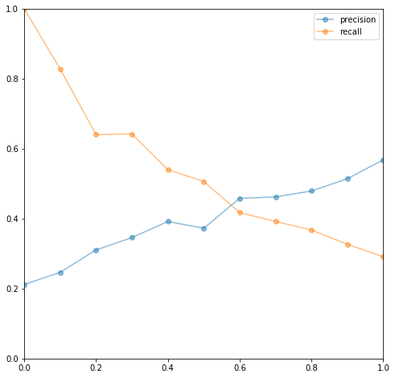

```python
plt.figure(figsize=(8,8))
plt.plot(rs, precisions,"o-",alpha=0.5,label="precision")
plt.plot(rs,recalls,"o-",alpha=0.5,label="recall")
plt.xlim(0,1)
plt.ylim(0,1)
plt.legend()
plt.show()
```

## 非線形分類器

※今回、非線形分類器の実行は割愛

[figure not shown]

### 非線形分類器のパラメータ

[figure not shown]

## まとめ

- Jubatusを使って分類をやってみた
- 分類の評価指標はたくさんあるので、**目的に合わせて選ぶ**
- データをうまく処理することで、線形分類器でも精度を上げることが可能

# NEXT : Jubakit

より簡単に分析が可能に！